# Modelos (Descriptiva, BIOCLIM, MAXENT, GLM, BRT & RF)

##### — BOOSTED REGRESSION TREES —

```r
# Modelo

brt1 <-  gbm.step(data=sdmdata, gbm.x = c(2,3,4,5), gbm.y = 1, tree.complexity=1, family = "bernoulli",  learning.rate = 0.01)
```

```
   GBM STEP - version 2.9

  Performing cross-validation optimisation of a boosted regression tree model
  for pb and using a family of bernoulli
  Using 1437 observations and 4 predictors
  creating 10 initial models of 50 trees

   folds are stratified by prevalence
  total mean deviance =  1.2443
  tolerance is fixed at  0.0012
  ntrees resid. dev.
  50    1.0503
  now adding trees...
  100   0.9629
  150   0.9088
```

[output cut: 39 more lines]

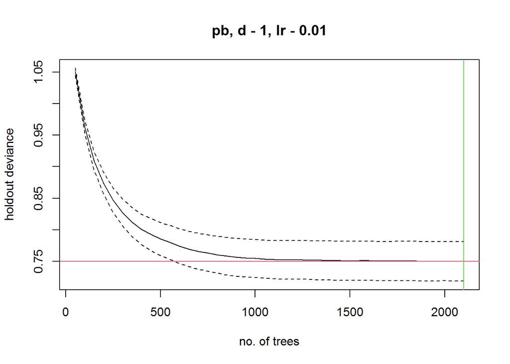

```
  mean total deviance = 1.244
  mean residual deviance = 0.685

  estimated cv deviance = 0.75 ; se = 0.031

  training data correlation = 0.699
  cv correlation =  0.658 ; se = 0.022

  training data AUC score = 0.91
  cv AUC score = 0.885 ; se = 0.01

  elapsed time -  0.35 minutes
```

```r
saveRDS(brt1, "C:/Users/Irene/Source/Repositorios/TFM-Irene-Extremera/RF y BRT/brt_model.rds")
```

(No es necesario interpretar e incluir la gráfica de holdout deviance en el TFM)

```r
# Análisis del modelo
devexpl <- ((brt1$self.statistics$null-brt1$self.statistics$resid)/brt1$self.statistics$null)*100
devexpl #% de deviance explicada por el modelo
```

```
  [1] 44.90898
```

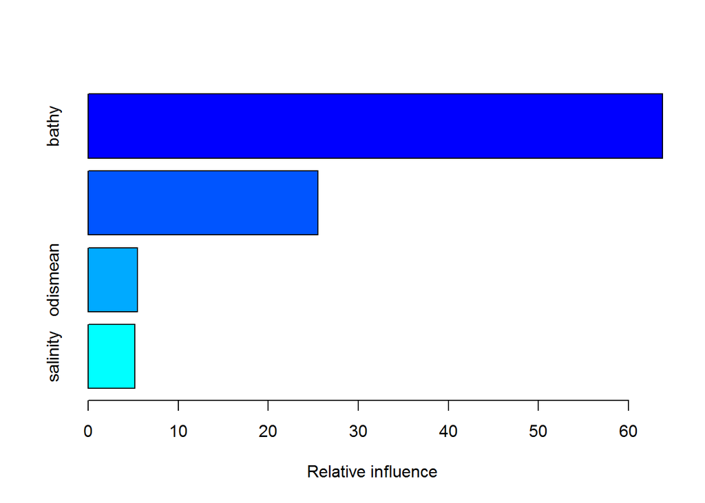

```
                var   rel.inf
  bathy       bathy 63.764792
  tempmean tempmean 25.522624
  odismean odismean  5.508439
  salinity salinity  5.204145
```

```r
summary(brt1) #% de deviance explicada por cada variable
```

Además. aproximadamente un 65% de la deviance es explicada por batimetría y cerca del 25% por parte de la temperatura media. En menor medida, 10% de lo que queda es explicado por las dos variables que quedan.

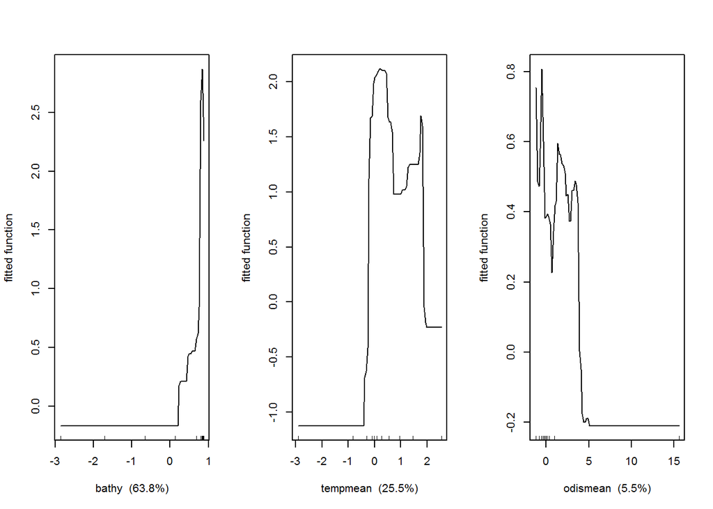

```r
# Plot de la respuesta funcional de la variable explicativa con respecto a la respuesta

gbm.plot(brt1, n.plots=3, write.title=FALSE, plot.layout=c(1,3), common.scale=F)
```

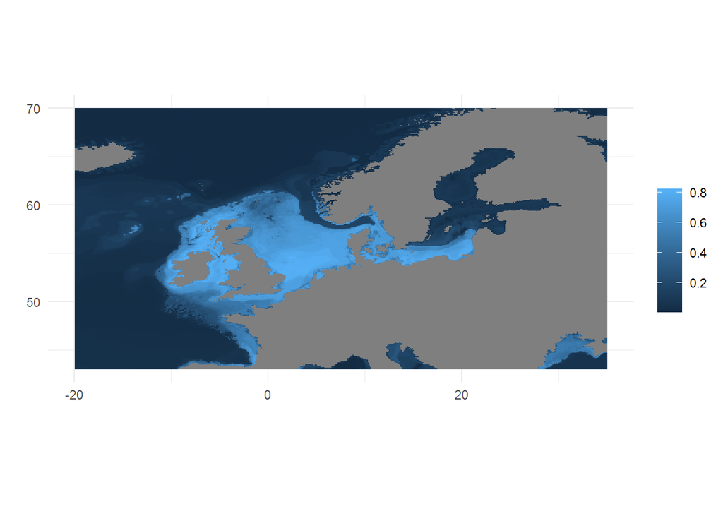

```r
# Predicción
pbrt <- predict(predictors3, brt1,type="response", n.trees=brt1$n.trees, shrinkage= 0.01, distribution="bernoulli")

# Representación
ggplot() +
  geom_raster(data = raster::as.data.frame(pbrt , xy = TRUE) , aes(x = x, y = y, fill = layer)) +
  coord_equal() +
  labs( x = "", y = "")+theme_minimal()+
  scale_color_brewer(palette = 'YlGnBu')+ labs(fill='')
```

```r
saveRDS(pbrt , "C:/Users/Irene/Source/Repositorios/TFM-Irene-Extremera/RF y BRT/Predicciones_brt_Atl.ascii")
```

Se aprecia que hay una gran probabilidad de presencia cerca de la costa, en especial alrededor de Reino Unido e Irlanda.

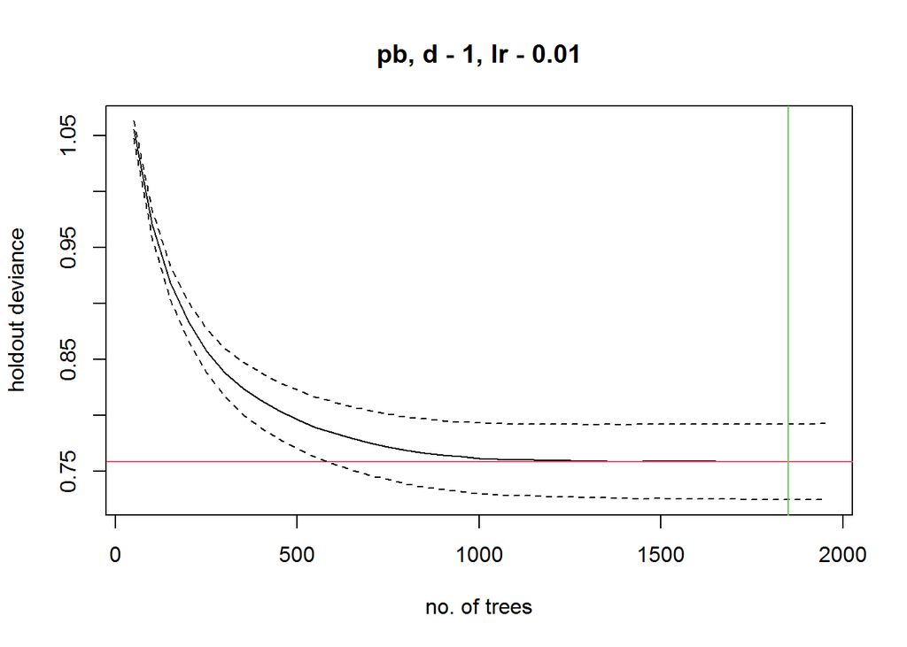

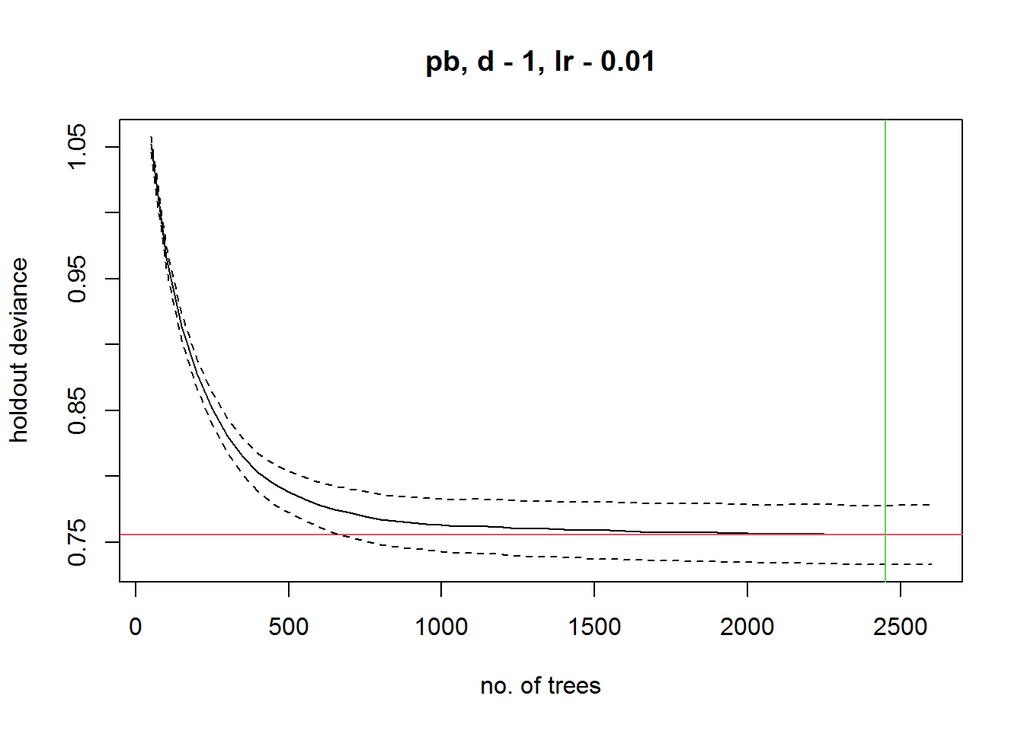

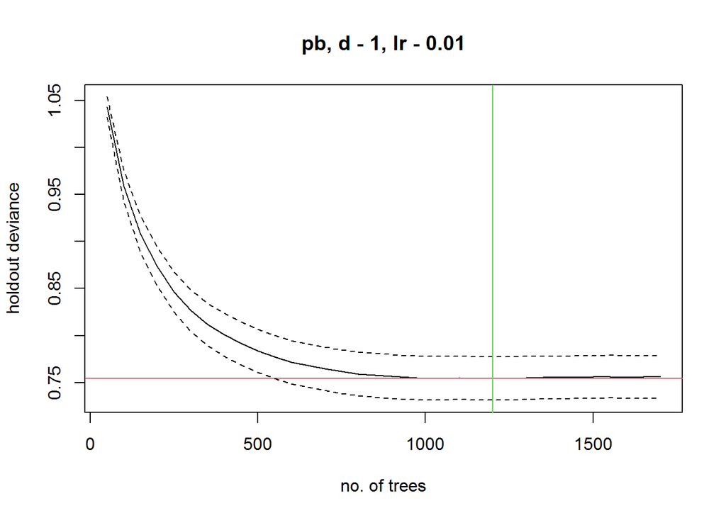

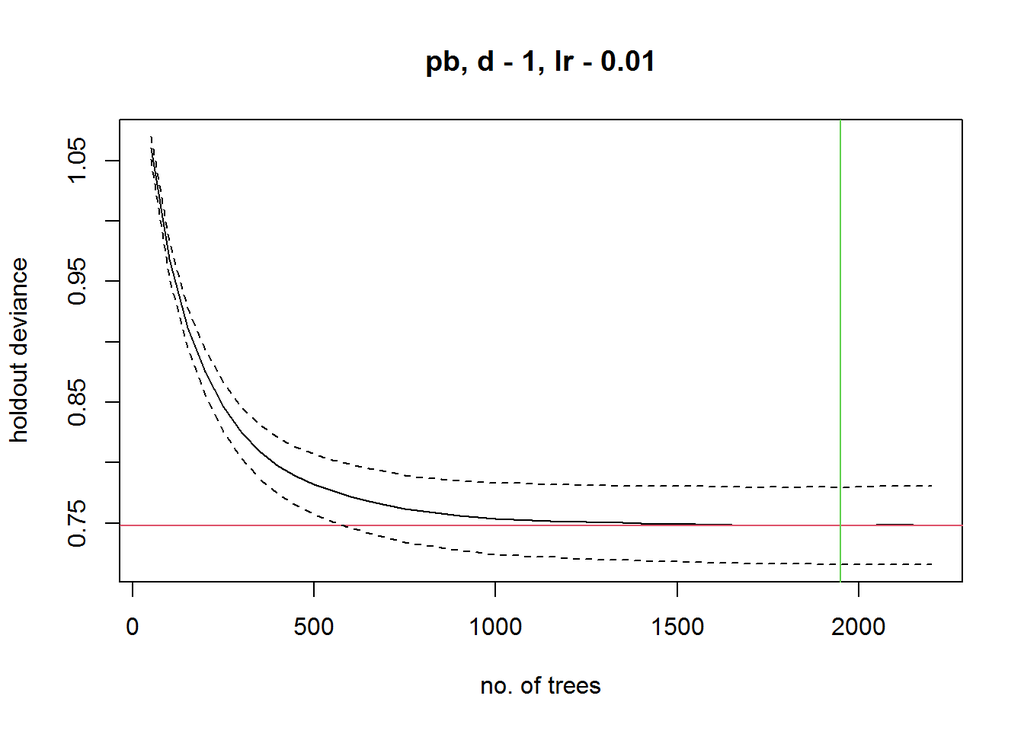

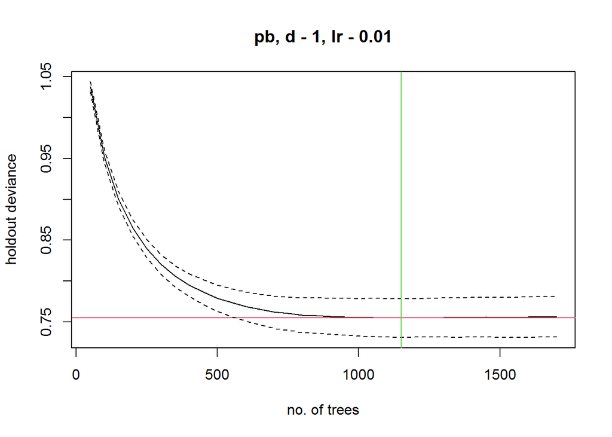

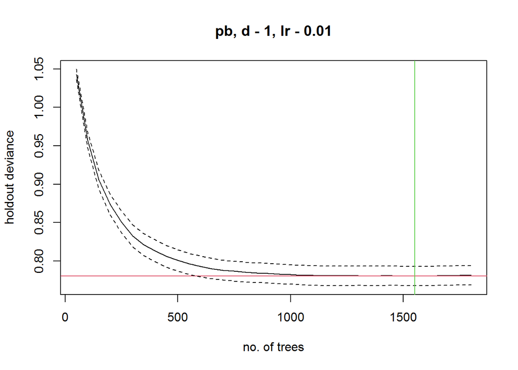

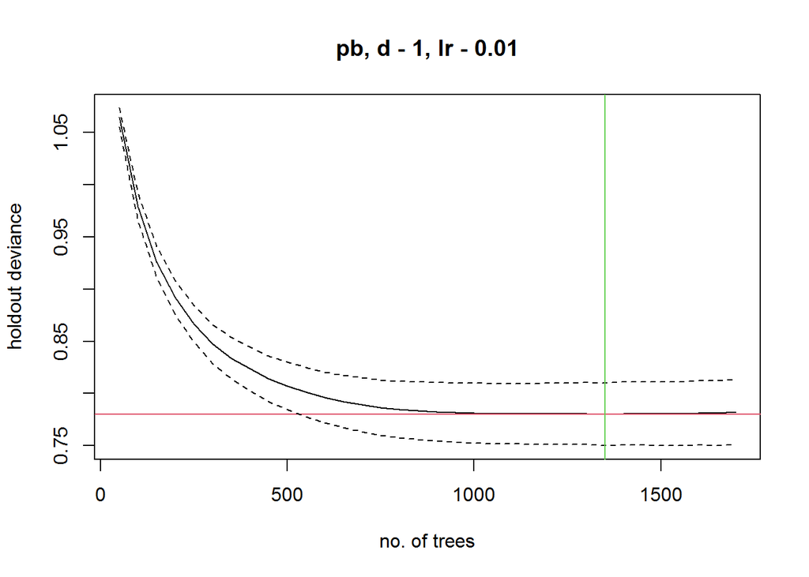

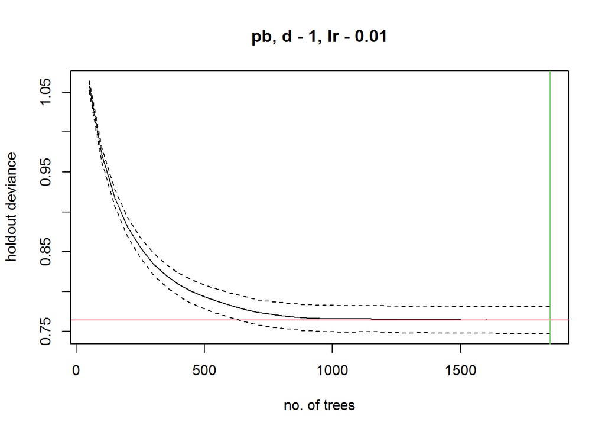

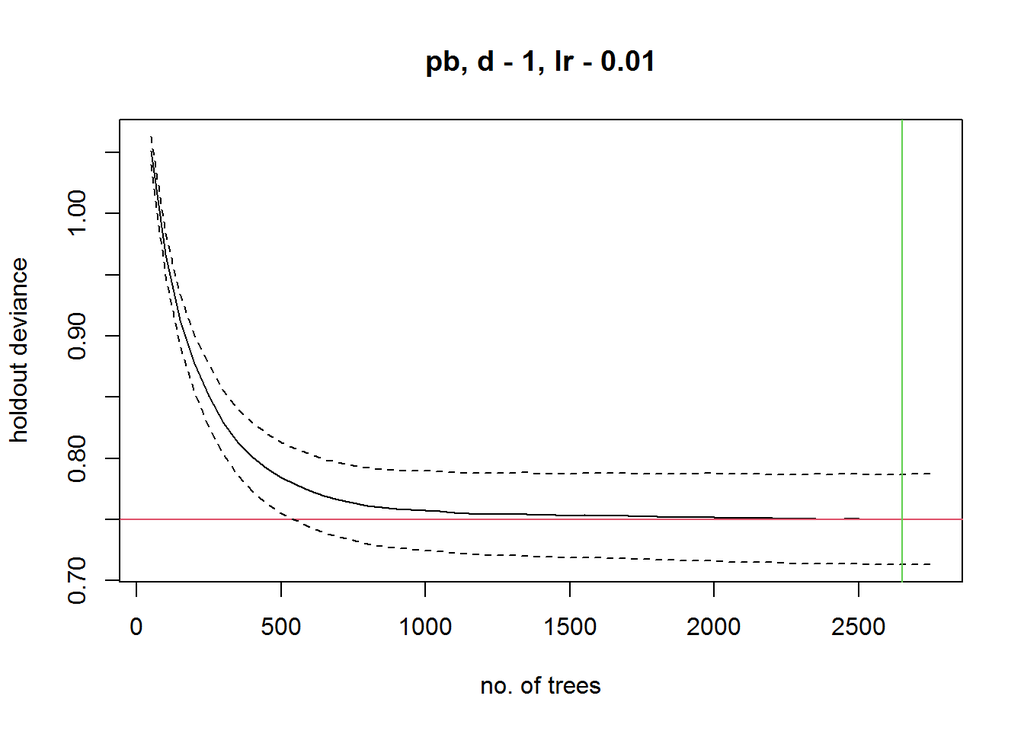

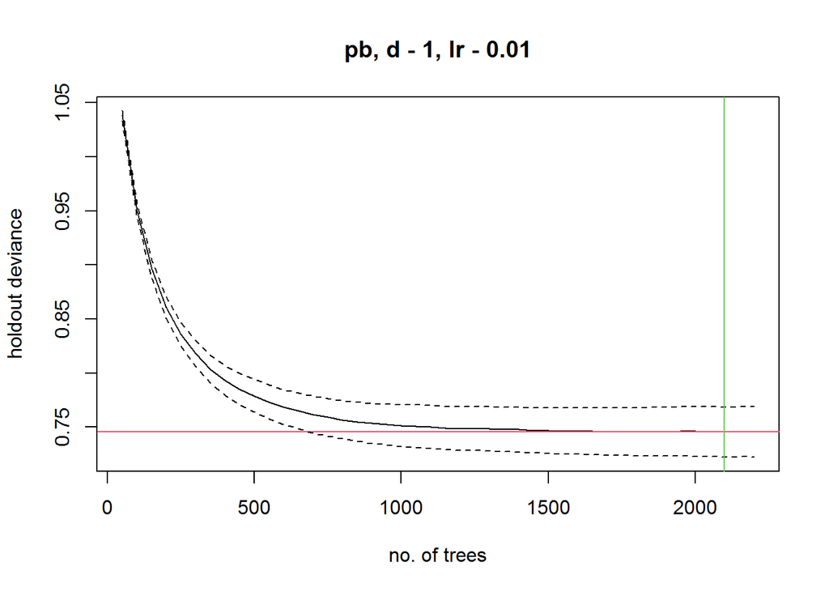

```r
# Validación Cruzada
fddmx3 <- function(coordenadas, base_datos,background){

      group <- kfold(coordenadas, 5) #kfold(1:1592, 5)

      pres_train <- base_datos[group != 1, ] #Las que no sean 1
      pres_test <- base_datos[group == 1, ] #Las que sean 1

      model <- gbm.step(data=pres_train, gbm.x = c(2,3,4,5), gbm.y = 1, tree.complexity=1, family = "bernoulli",  learning.rate = 0.01)

      group <- kfold(background, 5) #Hago 5 grupos de esos puntos
      backg_train <- background[group != 1, ]
      backg_test <- background[group == 1, ]

      eval.modesta <- evaluate(pres_test[pres_test==1,],pres_test[pres_test==0,],model)

      auc_modelo.model <- eval.modesta@auc #auc

      cor_modelo.model <- eval.modesta@cor #cor

      kappa_modelo.model <- mean(eval.modesta@kappa) #Kappa

      sensibility_modelo.model <- mean(eval.modesta@TPR/(eval.modesta@TPR+eval.modesta@FNR)) #Sensibilidad

      specificity_modelo.modelo <- mean(eval.modesta@TNR/(eval.modesta@FPR+eval.modesta@TNR)) #Especificidad

      TSS_modelo.model <- mean(eval.modesta@TPR+eval.modesta@TNR-1) #TSS

      return(c(auc_modelo.model,cor_modelo.model,kappa_modelo.model,sensibility_modelo.model,specificity_modelo.modelo,TSS_modelo.model))
}

# Hago una matriz para guardar los valores de los coeficientes de las diez iteraciones que me devuelva la función
cosites_brt <- matrix(ncol=6,nrow=10)

# Genereo un bucle for de 10 iteraciones que me devuelva 10 valores diferentes de los 6 coeficientes.
for (i in 1:10) {cosites_brt[i,] <- fddmx3(sdmdata[,c(6,7)],sdmdata,backgr)}
```

```r
# Le doy nombre a las columnas para saber qué coeficientes hay dentro
colnames(cosites_brt) <- c('AUC','COR','Kappa','Sensitivity','Specificity','TSS')

# Hago la media por columnas que es lo que me interesa y lo guardo
coef_brt_model <- apply(cosites_brt, 2, mean)

# Hago la media por columnas que es lo que me interesa y lo guardo
write.csv(coef_brt_model,'C:/Users/Irene/Source/Repositorios/TFM-Irene-Extremera/RF y BRT//coeficientes_brt.csv')
coef_brt <- read.csv('C:/Users/Irene/Source/Repositorios/TFM-Irene-Extremera/RF y BRT//coeficientes_brt.csv')
```

```r
coef_brt_model
```

```
          AUC         COR       Kappa Sensitivity Specificity         TSS
    0.8808146   0.6224359   0.3597341   0.7331805   0.6618633   0.3950437
```

```r
# CORRELACIÓN ESPACIAL
#Hago la matriz de vecinos para calcular el índice de Moran

nb <- dnearneigh(as.matrix(sdmdata[,c(6,7)]), 1,max(sdmdata[,c(6,7)]));nb
```

```
  Neighbour list object:
  Number of regions: 1437
  Number of nonzero links: 2053356
  Percentage nonzero weights: 99.43762
  Average number of links: 1428.919
```

```r
listw <- nb2listw(nb,style = "S")
```

```r
MoranI <- moran.test(residuals(brt1), listw=listw, randomisation=FALSE); MoranI #p valor de 1 indica que Ho no se rechaza, no hay autocorrelación espacial
```

```
    Moran I test under normality

  data:  residuals(brt1)
  weights: listw

  Moran I statistic standard deviate = -7.681, p-value = 1
  alternative hypothesis: greater
  sample estimates:
  Moran I statistic       Expectation          Variance
      -1.228130e-03     -6.963788e-04      4.792692e-09
```

```r
Moran_MC <- moran.mc(residuals(brt1), listw=listw, nsim=100); Moran_MC #p valor de 0.9901 Ho no se rechaza, lo cual indica que no hay autocorrelación espacial
```

```
    Monte-Carlo simulation of Moran I

  data:  residuals(brt1)
  weights: listw
  number of simulations + 1: 101

  statistic = -0.0012281, observed rank = 1, p-value = 0.9901
  alternative hypothesis: greater
```

Según el ínidce de Moran no se aprecia autocorrelación espacial, lo cual puede ser debido a que estoy trabajando con un area muy grande.

##### — RANDOM FOREST —

```r
# Modelo
model <- pb ~ bathy+salinity+tempmean+odismean
rf1 <- randomForest(model, sdmdata);rf1
```

```
  Call:
   randomForest(formula = model, data = sdmdata)
                 Type of random forest: regression
                       Number of trees: 500
  No. of variables tried at each split: 1

            Mean of squared residuals: 0.1291933
                      % Var explained: 40.01
```

```r
saveRDS(rf1, "C:/Users/Irene/Source/Repositorios/TFM-Irene-Extremera/RF y BRT//RF_model.rds")
```

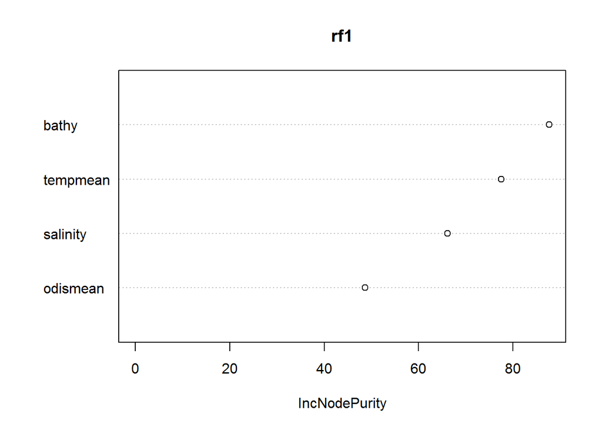

```r
varImpPlot(rf1)
```

Es un diagrama que representa lo importante que son las variables a la hora de realizar el Random Forest.

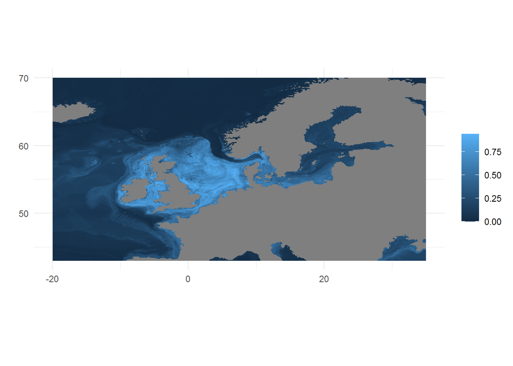

```r
# Predicción

pred_rf <- predict(predictors3, rf1,type="response") #Puedo hacer la predicción también

# rf.resid <- rf1$predicted - sdmdata$pb #calculate residual

saveRDS(pred_rf , "C:/Users/Irene/Source/Repositorios/TFM-Irene-Extremera/RF y BRT//Predicciones_RF_Atl.ascii")

ggplot() +
  geom_raster(data = raster::as.data.frame(pred_rf , xy = TRUE) , aes(x = x, y = y, fill = layer)) +
  coord_equal() +
  labs( x = "", y = "")+theme_minimal()+
  scale_color_brewer(palette = 'YlGnBu')+ labs(fill='')
```

El mapa anterior tiene un aspecto muy similar al de BRT sin embargo, la pobabilidad de presencia parece difuminarse considerablemente en comparación.

```r
# Validación Cruzada
fddmx4 <- function(coordenadas, base_datos ,background,modelo){

      group <- kfold(coordenadas, 5) #kfold(1:1592, 5)

      pres_train <- base_datos[group != 1, ] #Las que no sean 1
      pres_test <- base_datos[group == 1, ] #Las que sean 1

      model <- randomForest(modelo, pres_train)

      group <- kfold(background, 5) #Hago 5 grupos de esos puntos
      backg_train <- background[group != 1, ]
      backg_test <- background[group == 1, ]

      eval.modesta <- evaluate(pres_test[pres_test==1,],pres_test[pres_test==0,],model)

      auc_modelo.model <- eval.modesta@auc #auc

      cor_modelo.model <- eval.modesta@cor #cor

      kappa_modelo.model <- mean(eval.modesta@kappa) #Kappa

      sensibility_modelo.model <- mean(eval.modesta@TPR/(eval.modesta@TPR+eval.modesta@FNR)) #Sensibilidad

      specificity_modelo.modelo <- mean(eval.modesta@TNR/(eval.modesta@FPR+eval.modesta@TNR)) #Especificidad

      TSS_modelo.model <- mean(eval.modesta@TPR+eval.modesta@TNR-1) #TSS

      return(c(auc_modelo.model,cor_modelo.model,kappa_modelo.model,sensibility_modelo.model,specificity_modelo.modelo,TSS_modelo.model))
}

# Hago una matriz para guardar los valores de los coeficientes de las diez iteraciones que me devuelva la función
cosites_rf <- matrix(ncol=6,nrow=10)

# Genereo un bucle for de 10 iteraciones que me devuelva 10 valores diferentes de los 6 coeficientes.
for (i in 1:10) {cosites_rf[i,] <- fddmx4(sdmdata[,c(6,7)],sdmdata,backgr,model)}

# Le doy nombre a las columnas para saber qué coeficientes hay dentro
colnames(cosites_rf) <- c('AUC','COR','Kappa','Sensitivity','Specificity','TSS')

# Hago la media por columnas que es lo que me interesa y lo guardo
coef_rf_model <- apply(cosites_rf, 2, mean);coef_rf_model
```

```
          AUC         COR       Kappa Sensitivity Specificity         TSS
    0.8772602   0.6358049   0.3725071   0.7188316   0.6959065   0.4147381
```

```r
# Hago la media por columnas que es lo que me interesa y lo guardo
write.csv(coef_rf_model,'C:/Users/Irene/Source/Repositorios/TFM-Irene-Extremera/RF y BRT//coeficientes_rf.csv')
coef_glm <- read.csv('C:/Users/Irene/Source/Repositorios/TFM-Irene-Extremera/RF y BRT//coeficientes_rf.csv')
```

```r
####### AUTOCORRELACIÓN ESPACIAL #######
# ¿¿¿???
```

##### — MODELO LINEAL GENERALIZADO —

Debido a que la variable respuesta se distribuye como una binomial voy a realizar un GLM introduciendo las covariables de forma aditiva.

```r
# GLM
glm1 <- glm(pb ~ bathy + odismean + tempmean + salinity, data=sdmdata, family="binomial")

saveRDS(glm1, "C:/Users/Irene/Source/Repositorios/TFM-Irene-Extremera/GLM frecuentista//GLM_model.rds")

# Resumen del modelo
summary(glm1) #Todas las variables salen significativas
```

```
  Call:
  glm(formula = pb ~ bathy + odismean + tempmean + salinity, family = "binomial",
      data = sdmdata)

  Deviance Residuals:
      Min       1Q   Median       3Q      Max
  -1.6946  -0.9497  -0.0671   1.0736   4.8351

  Coefficients:
              Estimate Std. Error z value Pr(>|z|)
  (Intercept) -3.34564    0.35048  -9.546  < 2e-16 ***
  bathy        3.99900    0.44357   9.016  < 2e-16 ***
  odismean    -0.12642    0.04825  -2.620  0.00879 **
  tempmean     0.31625    0.10455   3.025  0.00249 **
  salinity     0.16479    0.06168   2.672  0.00755 **
  ---
  Signif. codes:  0 '***' 0.001 '**' 0.01 '*' 0.05 '.' 0.1 ' ' 1

  (Dispersion parameter for binomial family taken to be 1)

      Null deviance: 1788.0  on 1436  degrees of freedom
  Residual deviance: 1320.6  on 1432  degrees of freedom
  AIC: 1330.6

  Number of Fisher Scoring iterations: 8
```

Compruebo a continuación si hay colinealidad entre ellas.

```r
# Colinealidad

vif(glm1) #No la hay
```

```
     bathy odismean tempmean salinity
  1.073598 1.061428 1.156174 1.224153
```

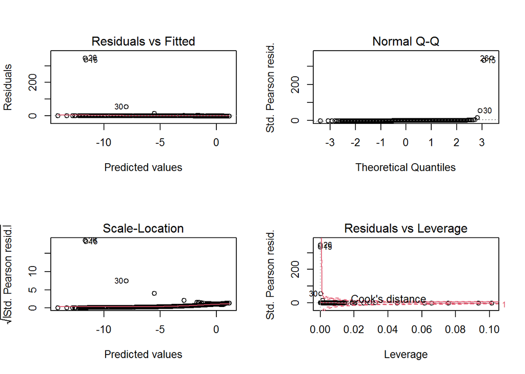

```r
# VALORACIÓN DEL MODELO:
# Normalidad y homocedasticidad

par(mfrow=c(2,2))
plot(glm1) #No se ve normalidad ni homocedasticidad en los residuos
```

Los residuos no son normales, obviamente porque la variable respuesta es una binomial.

```r
res_m1 <- residuals(glm1,type='deviance')
shapiro.test(res_m1) #No hay normalidad p valor de 2.2e-16
```

```
    Shapiro-Wilk normality test

  data:  res_m1
  W = 0.9007, p-value < 2.2e-16
```

```r
1-pchisq(glm1$deviance, df = glm1$df.residual, lower.tail = F) #0.0168 hay diferencias significativas entre el modelo nulo y el ajustado
```

```
  [1] 0.01678263
```

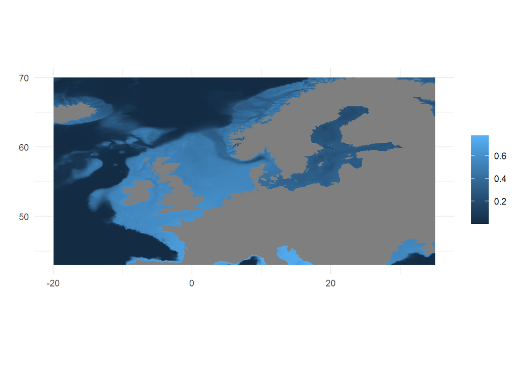

```r
# PREDICCIÓN
predm1<-predict(predictors3,glm1,type='response')

saveRDS(predm1, "C:/Users/Irene/Source/Repositorios/TFM-Irene-Extremera/GLM frecuentista//Predicciones_glm_Atl.ascii")

ggplot() +
  geom_raster(data = raster::as.data.frame(predm1 , xy = TRUE) , aes(x = x, y = y, fill = layer)) +
  coord_equal() +
  labs( x = "", y = "")+theme_minimal()+
  scale_color_brewer(palette = 'YlGnBu')+ labs(fill='')
```

En este mapa se aprecia que la probabilidad de presencia es menor en comparación al resto pero parece estar bastante extendida por por la mayor parte de la costa Europea, Mar del Norte y un poco en el Mar Báltico.

```r
coords <- as.data.frame(cbind(sdmdata$x,sdmdata$y)) #Extraigo la lat y long de los puntos obs
ppm1<-extract(predm1,coords) #Lo mismo con los valores de probabilidad de los puntos observados
ppm1<-as.data.frame(ppm1) #Paso a data.frame
sdmdata1<-cbind(sdmdata,ppm1) #Lo junto todo a una base de datos
sdmdata1<-na.omit(sdmdata1) #Elimino los NAs
cor(sdmdata1$ppm1,sdmdata1$pb,method="spearman") # 0.518 es la correlación entre lo predicho y lo observado
```

```
  [1] 0.4935927
```

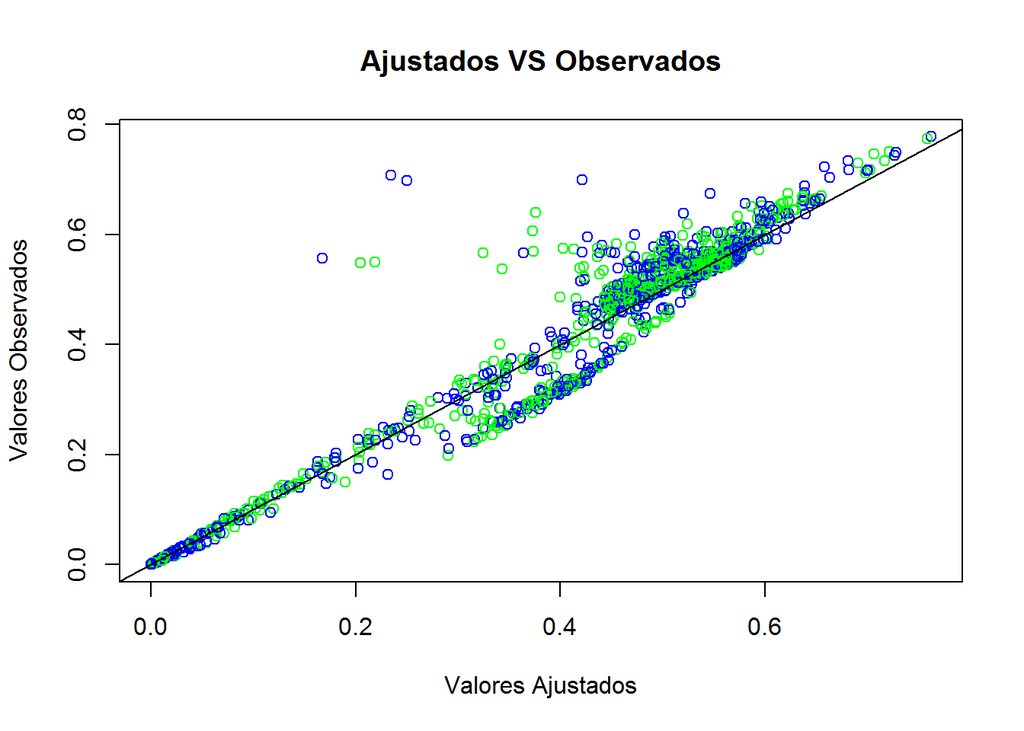

```r
plot(glm1$fitted.values, as.vector(unlist(ppm1)), main='Ajustados VS Observados', xlab='Valores Ajustados', ylab='Valores Observados',col=c('blue','green'))
abline(0,1)
```

```r
# length(as.vector(unlist(ppm1))) #Había que quitar ppm1 de la lista para poder introducirlo
```

La correlación entre lo predicho y observado es del 0.49. ¿?

```r
# FUNCIÓN DEFINITIVA DEFINITIVÍSIMA MILENARIA XTREM: Funciona para glm.
# Esta función sirve para hacer una cross validation y obtener así los distintos criterios de valoración del modelo que me interesan

fddmx2 <- function(coordenadas, base_datos,background,model){

      group <- kfold(coordenadas, 5) #kfold(1:1592, 5)

      pres_train <- base_datos[group != 1, ] #Las que no sean 1
      pres_test <- base_datos[group == 1, ] #Las que sean 1

      modelo <- update(model, data = pres_train)

      group <- kfold(background, 5) #Hago 5 grupos de esos puntos
      backg_train <- background[group != 1, ]
      backg_test <- background[group == 1, ]

      eval.modesta <- evaluate(pres_test[pres_test==1,],pres_test[pres_test==0,],modelo)

      auc_modelo.model <- eval.modesta@auc #auc

      cor_modelo.model <- eval.modesta@cor #cor

      kappa_modelo.model <- mean(eval.modesta@kappa) #Kappa

      sensibility_modelo.model <- mean(eval.modesta@TPR/(eval.modesta@TPR+eval.modesta@FNR)) #Sensibilidad

      specificity_modelo.modelo <- mean(eval.modesta@TNR/(eval.modesta@FPR+eval.modesta@TNR)) #Especificidad

      TSS_modelo.model <- mean(eval.modesta@TPR+eval.modesta@TNR-1) #TSS

      return(c(auc_modelo.model,cor_modelo.model,kappa_modelo.model,sensibility_modelo.model,specificity_modelo.modelo,TSS_modelo.model))
}

# Hago una matriz para guardar los valores de los coeficientes de las diez iteraciones que me devuelva la función
cosites_glm <- matrix(ncol=6,nrow=10)

# Genereo un bucle for de 10 iteraciones que me devuelva 10 valores diferentes de los 6 coeficientes.
for (i in 1:10) {cosites_glm[i,] <- fddmx2(sdmdata[,c(6,7)],sdmdata,backgr,glm1)}

# Le doy nombre a las columnas para saber qué coeficientes hay dentro
colnames(cosites_glm) <- c('AUC','COR','Kappa','Sensitivity','Specificity','TSS')

# Hago la media por columnas que es lo que me interesa y lo guardo
coef_glm_model <- apply(cosites_glm, 2, mean);coef_glm_model
```

```
          AUC         COR       Kappa Sensitivity Specificity         TSS
    0.8259171   0.4389645   0.2832544   0.7185673   0.6052258   0.3237930
```

```r
write.csv(coef_glm_model,'C:/Users/Irene/Source/Repositorios/TFM-Irene-Extremera/GLM Frecuentista/coeficientes_glmfrec.csv')
coef_glm <- read.csv('C:/Users/Irene/Source/Repositorios/TFM-Irene-Extremera/GLM frecuentista/coeficientes_glmfrec.csv')
```

```r
MoranI <- moran.test(residuals(glm1), listw=listw, randomisation=FALSE); MoranI #p valor de 1 indica que Ho no se rechaza, no hay autocorrelación espacial
```

```
    Moran I test under normality

  data:  residuals(glm1)
  weights: listw

  Moran I statistic standard deviate = -19.633, p-value = 1
  alternative hypothesis: greater
  sample estimates:
  Moran I statistic       Expectation          Variance
      -2.055571e-03     -6.963788e-04      4.792692e-09
```

```r
Moran_MC <- moran.mc(residuals(glm1), listw=listw, nsim=100); Moran_MC #p valor de 0.99 Ho no se rechaza, lo cual indica que no hay autocorrelación espacial
```

```
    Monte-Carlo simulation of Moran I

  data:  residuals(glm1)
  weights: listw
  number of simulations + 1: 101

  statistic = -0.0020556, observed rank = 1, p-value = 0.9901
  alternative hypothesis: greater
```

No hay correlación espacial. Lo cual puede ser debido a que el area de estudio es muy grande.

—– Comparación —–

```r
matriz <- matrix(ncol=6,nrow=5,c(coef_bc_model,coef_mx_model,coef_brt_model,coef_rf_model,coef_glm_model))
colnames(matriz) <- c("AUC","COR","Kappa","Sensitivity","Specificity","TSS")
rownames(matriz) <- c("BIOCLIM","MAXENT","BRT","RF","GLM")
matriz
```

[output not shown]